# Business Statistics Mid-Term Assessment IB94X0 2024-2025 #1

5624055 - Anuroop Ghosh

```r
#All required packages for the codes to run
library(tidyverse)
library(dplyr)
library(scales)
library(knitr)
```

# Section 1

## Data Dictionary

### Overview

- **Dataset Name:** York Footfall Data
- **Source:** [Link](https://my.wbs.ac.uk/$/$/$/event/cmsfile/t/item/i/1766014/v/4/f/1/n/York_Footfall_data.csv)

### Variable Definitions

| Variable Name | Description | Data Type | Format | Valid Values |
| --- | --- | --- | --- | --- |
| **Date** | Date of recorded data | Date | Date (YYYY-MM-DD) | 2015-01-01 to 2019-12-31 |
| **SiteName** | Name of the site | Character |  | York |
| **LocationName** | Name of the Location of collected data | Character |  | Church Street, Coney Street, Micklegate, Parliament Street, Parliament Street at M&S, Stonegate |
| **WeekDay** | Day of the week | Character |  | Monday, Tuesday, Wednesday, Thursday, Friday, Saturday, Sunday |
| **TotalCount** | Total number of footfall | Number/Numeric |  | 402 - 328310 |
| **Recording_ID** | ID of recorded data | Number/Numeric |  |  |

## Task 1

```r
#First we import  the data into a variable
York_Footfall_data <- read_csv("York_Footfall_data.csv")
#After importing the data we check for any duplicate values in the dataset
duplicates <- York_Footfall_data[duplicated(York_Footfall_data), ]
duplicates
```

```
## # A tibble: 0 × 6
## # ℹ 6 variables: Date <date>, SiteName <chr>, LocationName <chr>,
## #   WeekDay <chr>, TotalCount <dbl>, Recording_ID <dbl>
```

We observe that there are no duplicates in the data.

```r
#Now we check the number of missing values in each column of the dataset
print(summary(is.na(York_Footfall_data)))
```

```
##     Date          SiteName       LocationName     WeekDay
##  Mode :logical   Mode :logical   Mode :logical   Mode :logical
##  FALSE:8204      FALSE:8204      FALSE:8204      FALSE:8204
##
##  TotalCount      Recording_ID
##  Mode :logical   Mode :logical
##  FALSE:8194      FALSE:8104
##  TRUE :10        TRUE :100
```

The dataset has 110 missing values, with 10 in the TotalCount column and 100 in the Recording_ID column. For our analysis, we interpret Recording_ID as an identifier linked to the footfall count for a specific day, and we assume that its missing values are likely due to a technical issue. There is a chance these missing Recording_ID values could indicate errors in footfall data entry; however, due to limited information, we decide that Recording_ID is not critical for our analysis. Therefore, we only address the missing values in TotalCount to move forward.

```r
#Storing in a new variable for ease of operation
data <- York_Footfall_data %>%
  filter(!is.na(TotalCount))

#We check the data now
str(data)
```

```
## spc_tbl_ [8,194 × 6] (S3: spec_tbl_df/tbl_df/tbl/data.frame)
##  $ Date        : Date[1:8194], format: "2015-01-01" "2015-01-01" ...
##  $ SiteName    : chr [1:8194] "York" "York" "York" "York" ...
##  $ LocationName: chr [1:8194] "Church Street" "Coney Street" "Micklegate" "Parliament Street at M&S" ...
##  $ WeekDay     : chr [1:8194] "Thursday" "Thursday" "Thursday" "Thursday" ...
##  $ TotalCount  : num [1:8194] 1952 12220 5559 7802 14004 ...
##  $ Recording_ID: num [1:8194] 375836 724862 451020 523989 382272 ...
##  - attr(*, "spec")=
##   .. cols(
##   ..   Date = col_date(format = ""),
##   ..   SiteName = col_character(),
##   ..   LocationName = col_character(),
##   ..   WeekDay = col_character(),
##   ..   TotalCount = col_double(),
##   ..   Recording_ID = col_double()
##   .. )
##  - attr(*, "problems")=<externalptr>
```

```r
unique(data$SiteName)
```

```
## [1] "York"
```

```r
unique(data$LocationName)
```

```
## [1] "Church Street"            "Coney Street"
## [3] "Micklegate"               "Parliament Street at M&S"
## [5] "Stonegate"                "Parliament Street"
```

```r
unique(data$WeekDay)
```

```
## [1] "Thursday"  "Friday"    "Saturday"  "Sunday"    "Monday"    "Tuesday"
## [7] "Wednesday"
```

We see all the data is for the Site of York and the days of the week are also entered correctly without any spelling mistakes, but we notice two location names ‘Parliament Street’ and ‘Parliament Street at M&S’, with similar names. Upon cross-checking with our Reference 2 and 3 we find that, ‘Parliament Street’ and ‘Parliament Street at M&S’ refers to the same place, which could indicate towards a potential data entry error. In order to fix that, we will update the data by renaming both of them as ‘Parliament Street’.

```r
#Updating the data by renaming Parliament Street at M&S to Parliament Street
data <- data %>%
  mutate(LocationName = ifelse(LocationName == "Parliament Street at M&S", "Parliament Street", LocationName))
```

Now we shall visualize the data.

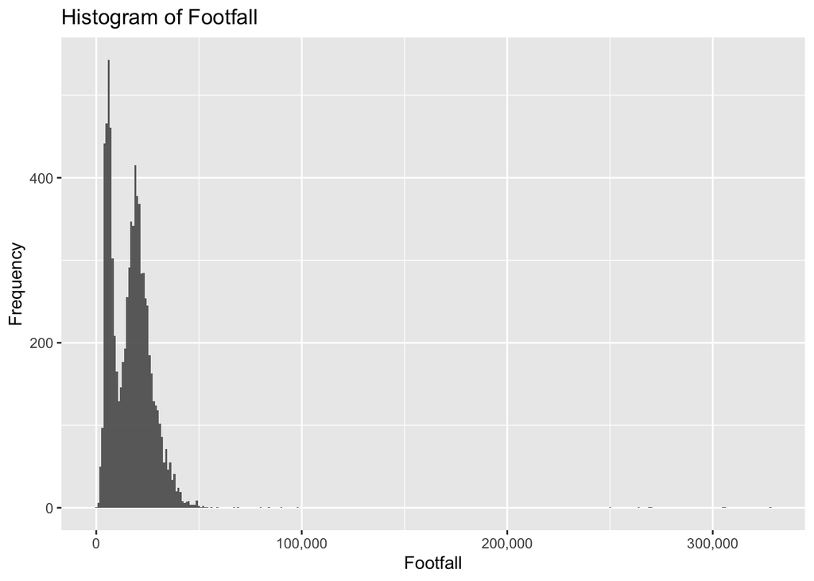

```r
#Using Histogram
ggplot(data, aes(x = TotalCount) ) +
  geom_histogram(alpha = 0.9, binwidth = 1000) +
  scale_x_continuous(labels = comma) +
  labs(title = "Histogram of Footfall", x = "Footfall", y = "Frequency")
```

Visually, the data does not appear to be Normal, which we try confirming using the Kolmogoroz-Smirnov Test and Q-Q Plot.

```r
ks.test(data$TotalCount, "pnorm", mean=mean(data$TotalCount, sd=sd(data$TotalCount)))
```

```
##
##  Asymptotic one-sample Kolmogorov-Smirnov test
##
## data:  data$TotalCount
## D = 0.50481, p-value < 2.2e-16
## alternative hypothesis: two-sided
```

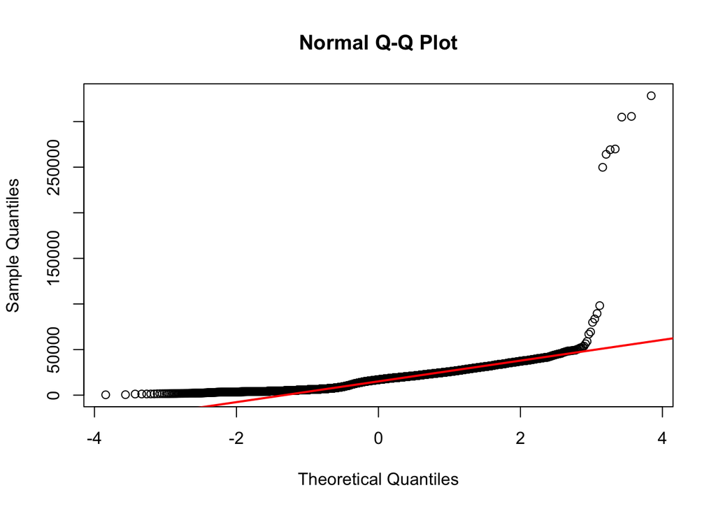

```r
qqnorm(data$TotalCount)
qqline(data$TotalCount, col = "red", lwd = 2)
```

We observe that the p-value is extremely low (<0.05) and the D statistic value is extremely high (>0.05). Furthermore, the Q-Q Plot also shows that multiple data points deviate significantly from the theoretical quantile line. Both these observations help us conclude that the data is not normal or does not follow a normal distribution.

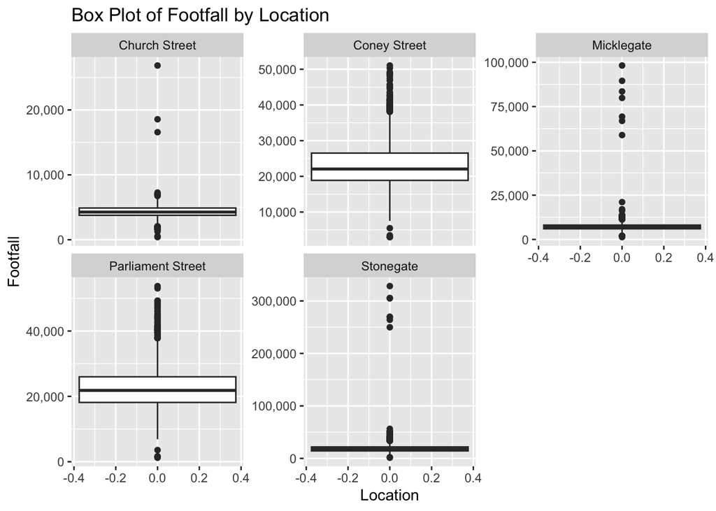

```r
#Now we shall visualize the data for outliers
#We use Boxplot
ggplot(data, aes(y = TotalCount)) +
  geom_boxplot() +
  facet_wrap(~LocationName, ncol = 3,scales = "free_y") +
  scale_y_continuous(labels = comma) +
  labs(title = "Box Plot of Footfall by Location", y = "Footfall", x = "Location")
```

We observe quite a few outliers in the data. In order to be certain, we will examine it further using z-score/standard score method.

```r
z_scores <- scale(data$TotalCount)
sigma <- 3
outlier <- data$TotalCount[abs(z_scores) > sigma]
outlier
```

```
##  [1]  56371  69320 269930  66910 249850  79870 264110  89530 305700  98180
## [11] 328310  83540 304890  58920 269140
```

We observe a total of 15 values that are outliers. This prompts us to proceed with the data with two approaches, data with outliers and data without the outliers respectively.

## Task 1.1(Data with Outliers)

Now we shall create two summary tables (for the two datas) that will show the following for each location where footfall was measured: - The date of the first and last day when footfall was measured at this location - The mean daily footfall - The standard deviation of the daily footfall - The highest daily footfall - The lowest daily footfall

```r
#Summary Table 1
summary_table_1 <- data %>%
  group_by(LocationName) %>%
  summarise(First_Footfall_day = min(Date),
Last_Footfall_Day = max(Date),
Mean_Daily_Footfall = mean(TotalCount),
Standard_Deviation_of_Daily_Footfall = sd(TotalCount),
Highest_Daily_Footfall = max(TotalCount),
Lowest_Daily_Footfall = min(TotalCount))
```

Now we display this in an organized form to make it more presentable using knitr commands.

```r
knitr::kable(summary_table_1,
             caption = "Summary Table with Outliers",
             booktabs = TRUE,
             col.names = c("Name of Location","First Date of Recorded Footfall", "Last Date of Recorded Footfall", "Mean Daily Footfall", "Standard Deviation of Daily Footfall", "Highest Daily Footfall", "Lowest Daily Footfall"))
```

Summary Table with Outliers

| Name of Location | First Date of Recorded Footfall | Last Date of Recorded Footfall | Mean Daily Footfall | Standard Deviation of Daily Footfall | Highest Daily Footfall | Lowest Daily Footfall |
| --- | --- | --- | --- | --- | --- | --- |
| Church Street | 2015-01-01 | 2017-06-18 | 4352.429 | 1388.959 | 26848 | 402 |
| Coney Street | 2015-01-01 | 2019-12-31 | 23507.291 | 6608.089 | 51050 | 2960 |
| Micklegate | 2015-01-01 | 2019-12-31 | 7486.890 | 4800.012 | 98180 | 1309 |
| Parliament Street | 2015-01-01 | 2019-12-31 | 22614.147 | 6714.429 | 53749 | 1227 |
| Stonegate | 2015-01-01 | 2019-12-31 | 19901.796 | 17826.401 | 328310 | 1297 |

We will proceed similarly for data without outliers.

## Task 1.2(Data without outliers)

```r
#Storing the no-outlier data in a new variable
data_no_outlier <- data %>%
  filter(!abs(z_scores) > sigma)
#Summary Table 2
summary_table_2 <- data_no_outlier %>%
  group_by(LocationName) %>%
  summarise(First_Footfall_day = min(Date),
Last_Footfall_Day = max(Date),
Mean_Daily_Footfall = mean(TotalCount),
Standard_Deviation_of_Daily_Footfall = sd(TotalCount),
Highest_Daily_Footfall = max(TotalCount),
Lowest_Daily_Footfall = min(TotalCount))

#Displaying the table
knitr::kable(summary_table_2,
             caption = "Summary Table without Outliers",
             booktabs = TRUE,
             col.names = c("Name of Location","First Date of Recorded Footfall", "Last Date of Recorded Footfall", "Mean Daily Footfall", "Standard Deviation of Daily Footfall", "Highest Daily Footfall", "Lowest Daily Footfall"))
```

Summary Table without Outliers

| Name of Location | First Date of Recorded Footfall | Last Date of Recorded Footfall | Mean Daily Footfall | Standard Deviation of Daily Footfall | Highest Daily Footfall | Lowest Daily Footfall |
| --- | --- | --- | --- | --- | --- | --- |
| Church Street | 2015-01-01 | 2017-06-18 | 4352.429 | 1388.959 | 26848 | 402 |
| Coney Street | 2015-01-01 | 2019-12-31 | 23507.291 | 6608.089 | 51050 | 2960 |
| Micklegate | 2015-01-01 | 2019-12-31 | 7215.389 | 1806.757 | 21082 | 1309 |
| Parliament Street | 2015-01-01 | 2019-12-31 | 22614.147 | 6714.429 | 53749 | 1227 |
| Stonegate | 2015-01-01 | 2019-12-31 | 18862.694 | 6697.096 | 51916 | 1297 |

## Task 2

For the next analyses, we will be working with data from the year 2019 (the last full year before the COVID pandemic).

```r
#Importing the 2019 data in a new variable
data2019 <- data %>%
  filter(grepl("2019",Date))
```

Now we shall visualize the data.

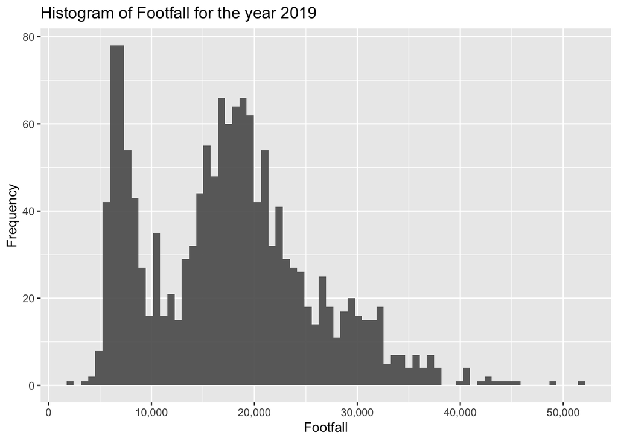

```r
#Using Histogram
ggplot(data2019, aes(x = TotalCount) ) +
  geom_histogram(alpha = 0.9, binwidth = 700) +
  scale_x_continuous(labels = comma) +
  labs(title = "Histogram of Footfall for the year 2019", x = "Footfall", y = "Frequency")
```

We observe that the 2019 data is skewed and it does not appear to follow a Normal Distribution either. We shall further confirm this using Kolmogorov-Smirnov Test and Q-Q Plot.

```r
ks.test(data2019$TotalCount, "pnorm", mean=mean(data2019$TotalCount, sd=sd(data2019$TotalCount)))
```

```
##
##  Asymptotic one-sample Kolmogorov-Smirnov test
##
## data:  data2019$TotalCount
## D = 0.50616, p-value < 2.2e-16
## alternative hypothesis: two-sided
```

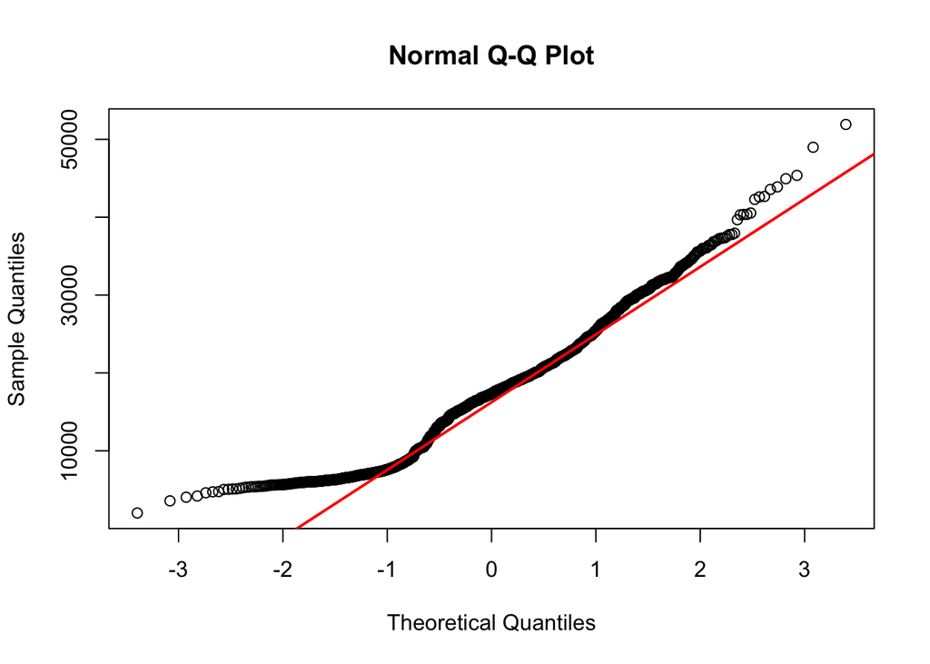

```r
qqnorm(data2019$TotalCount)
qqline(data2019$TotalCount, col = "red", lwd = 2)
```

We observe that the p-value is extremely low (<0.05) and the D statistic value is extremely high (>0.05). Furthermore, the Q-Q Plot also shows that multiple data points deviate significantly from the theoretical quantile line. Both these observations help us conclude that the data is not normal or does not follow a normal distribution.

Now we shall visualize the data for outliers.

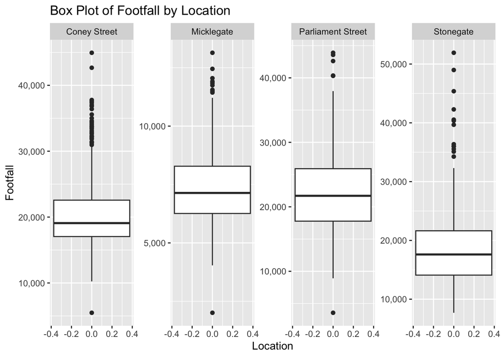

```r
#We use Boxplot
ggplot(data2019, aes(y = TotalCount)) +
  geom_boxplot() +
  facet_wrap(~LocationName, ncol = 4,scales = "free_y") +
  scale_y_continuous(labels = comma) +
  labs(title = "Box Plot of Footfall by Location", y = "Footfall", x = "Location")
```

We can observe multiple outliers in the 2019 data. We will be working with z-scores once again to check for the present outliers in the data.

```r
z_scores_2 <- scale(data2019$TotalCount)
sigma <- 3
outlier_2 <- data2019$TotalCount[abs(z_scores) > sigma]
outlier_2
```

```
##  [1] NA NA NA NA NA NA NA NA NA NA NA NA NA NA NA
```

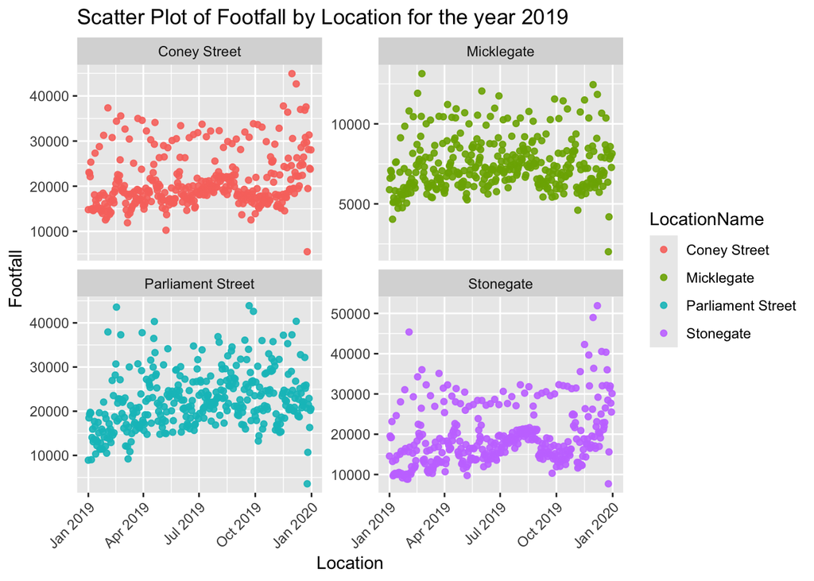

```r
ggplot(data2019, aes(x = Date, y = TotalCount, color = LocationName) ) +
  geom_point(alpha = 0.9) +
  facet_wrap(~LocationName, nrow = 3,scales = "free_y") +
  labs(title = "Scatter Plot of Footfall by Location for the year 2019", y = "Footfall", x = "Location") +
  theme(axis.text.x = element_text(angle = 45, hjust = 1))
```

Now to show the distribution of footfall across all days in the dataset, separated by each Location Name, we will be using a Histogram.

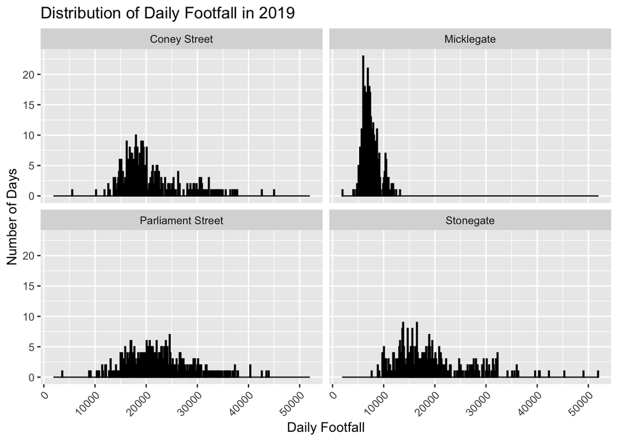

```r
#Histogram
ggplot(data2019, aes(x = TotalCount)) +
  geom_histogram(binwidth = 150, fill = "steelblue", color = "black") +  # Adjust binwidth as needed
  labs(title = "Distribution of Daily Footfall in 2019",
       x = "Daily Footfall",
       y = "Number of Days") +
  facet_wrap(~LocationName) +
  theme(axis.text.x = element_text(angle = 45, hjust = 1))
```

For the next parts, we store the datas of Coney Street and Stonegate in separate variables.

```r
#We store the Coney Street Data in a variable
Coney_Street_data_2019 <- data2019 %>%
  filter(grepl("Coney Street",LocationName,ignore.case = TRUE))

#We do the same for Stonegate
Stonegate_data_2019 <- data2019 %>%
  filter(grepl("Stonegate",LocationName,ignore.case = TRUE))
```

Now, in order to perform the t-tests, we compare the variances of both the locations and proceed with the t-test according to our findings.

```r
#For data with outliers
#We compare the variances of both the datasets
var(Coney_Street_data_2019$TotalCount) == var(Stonegate_data_2019$TotalCount)
```

```
## [1] FALSE
```

```r
#We perform Welch t-test as their variances are unequal
t_test_1 <- t.test(Coney_Street_data_2019$TotalCount, Stonegate_data_2019$TotalCount, alternative = "two.sided", var.equal = FALSE)
print(t_test_1)
```

```
##
##  Welch Two Sample t-test
##
## data:  Coney_Street_data_2019$TotalCount and Stonegate_data_2019$TotalCount
## t = 3.3611, df = 699.18, p-value = 0.0008186
## alternative hypothesis: true difference in means is not equal to 0
## 95 percent confidence interval:
##   670.9189 2555.7989
## sample estimates:
## mean of x mean of y
##  20817.45  19204.09
```

Next, we proceed with our analysis for the weekend data for Coney Street and Stonegate.

```r
#We store Weekend Data for Coney Street
Coney_Street_Weekend_2019 <- Coney_Street_data_2019 %>%
  filter(WeekDay %in% c("Saturday", "Sunday"), ignore.case = TRUE)

#Similarly for Stonegate
Stonegate_Weekend_2019 <- Stonegate_data_2019 %>%
  filter(WeekDay %in% c("Saturday", "Sunday"), ignore.case = TRUE)

#We compare the variances of these two datasets
var(Coney_Street_Weekend_2019$TotalCount) == var(Stonegate_Weekend_2019$TotalCount)
```

```
## [1] FALSE
```

```r
#We perform Welch t-test for the weekend data as their variances are also unequal
t_test_2 <- t.test(Coney_Street_Weekend_2019$TotalCount, Stonegate_Weekend_2019$TotalCount, alternative = "two.sided", var.equal = FALSE)
print(t_test_2)
```

```
##
##  Welch Two Sample t-test
##
## data:  Coney_Street_Weekend_2019$TotalCount and Stonegate_Weekend_2019$TotalCount
## t = -0.29072, df = 203.88, p-value = 0.7716
## alternative hypothesis: true difference in means is not equal to 0
## 95 percent confidence interval:
##  -2362.601  1755.409
## sample estimates:
## mean of x mean of y
##  25863.37  26166.96
```

# Section 2

## Objective

In this project, we analyzed footfall data from York, focusing on 2019.Our objective was to advise a promoter on the best site to put their stall, primarily between Coney Street and Stonegate, in order to draw as many people as possible during the week, and on the weekends.

## Insights

### Overall Footfall Comparison:

1. Coney Street had a consistently higher average footfall than Stonegate over the entire week.
2. Statistical analysis suggests there is a 95% chance that the difference in average footfall between these locations ranges from an additional 671 to 2,556 people at Coney Street. This means that placing a stall at Coney Street could potentially lead to significantly more foot traffic.

### Weekend Footfall Comparison:

1. For weekends specifically, we observed that both locations have similar average footfall numbers.
2. There’s a 95% probability that the difference in average weekend footfall could vary, potentially from a decrease of 2,362 people to an increase of 1,755 people at Coney Street. This wider range indicates that weekend foot traffic is more variable.

# References

1. Fundamentals of Mathematical Statistics - S.C. Gupta, V.K. Kapoor
2. [Arcgis Hub - City of York Council](https://hub.arcgis.com/datasets/CYC::footfall-cameras/explore?location=53.958999%2C-1.084650%2C14.98)
3. Google Maps - Parliament Street, York
4. [RMarkdown Cheat Sheet](https://github.com/rstudio/cheatsheets/raw/main/rmarkdown-2.0.pdf)
5. [Gemini AI](https://gemini.google.com/app)
6. [ChatGPT AI](https://chatgpt.com)
7. [WBS Individual Assignment Question and Guidance](https://my.wbs.ac.uk/$/$/$/event/cmsfile/t/item/i/1766014/v/4/f/2/n/Individual-Assignment-1-IB94X---4--5-.pdf)
8. [WBS Business Statistics Forum](https://my.wbs.ac.uk/-/academic/337712/forums/forum/354921/topic/1767072/#post_1058890)